# project 1

# data visualization

```python
import matplotlib.pyplot as plt
```

```python
import seaborn as sns
```

### BMW yearly trends

```
 This chart shows the reflecting changes in market conditions and customer demands
```

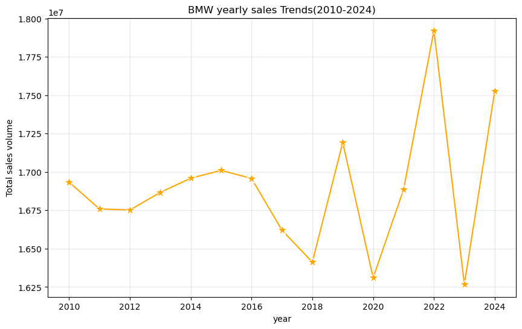

```python
plt.figure(figsize=(10,6))
sns.lineplot(data=df,x="Year",y="Sales_Volume",estimator="sum",ci=None,marker="*",color="orange",markersize="12")
plt.title("BMW yearly sales Trends(2010-2024)")
plt.xlabel("year")
plt.ylabel("Total sales volume")
plt.grid(True,alpha=0.3)
plt.show()
```

### BMW sales distribution by region

This chart help to compare which region contributes more to BMW's total sales

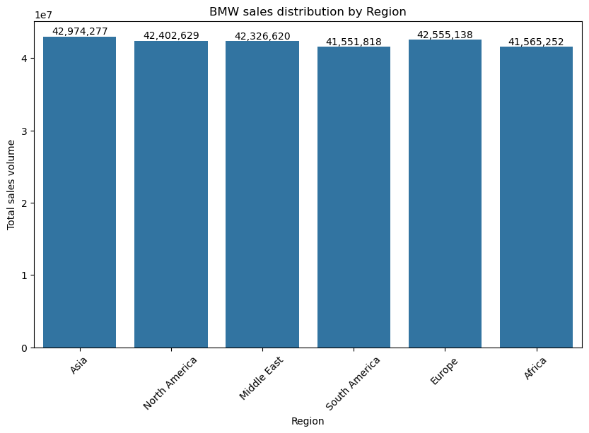

```python
plt.figure(figsize=(10,6))
ax=sns.barplot(data=df,x="Region",y="Sales_Volume",estimator="sum",ci=None)

plt.title("BMW sales distribution by Region")
plt.xlabel("Region")
plt.ylabel("Total sales volume")
plt.xticks(rotation=45)

for p in ax.patches:
    ax.annotate(
        format(int(p.get_height()),','),
        (p.get_x()+p.get_width()/2.,
         p.get_height()),
        ha='center',va='bottom',
        fontsize=10
    )
plt.show()
```

### BMW top best selling models

This chart helps to identify the customer preference , high demand models ands Models to focus on for marketing and production

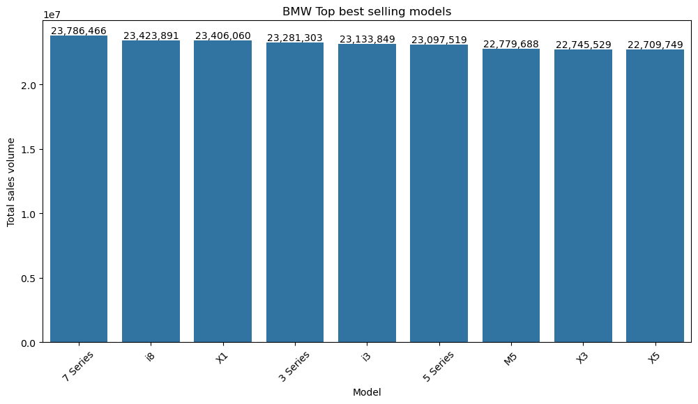

```python
top_models=df.groupby("Model")["Sales_Volume"].sum().sort_values(ascending=False).head(9)
plt.figure(figsize=(12,6))
ax=sns.barplot(x=top_models.index,y=top_models.values)
plt.title("BMW Top best selling models")
plt.ylabel("Total sales volume")
plt.xlabel("Model")
plt.xticks(rotation=45)
for p in ax.patches:
    ax.annotate(
        format(int(p.get_height()),','),
        (p.get_x()+p.get_width()/2.,
         p.get_height()),
        ha='center',va='bottom',
        fontsize=10
    )

plt.show()
```

### Hexbin plot of Mileage(KM) and Price(USD)

[output not shown]

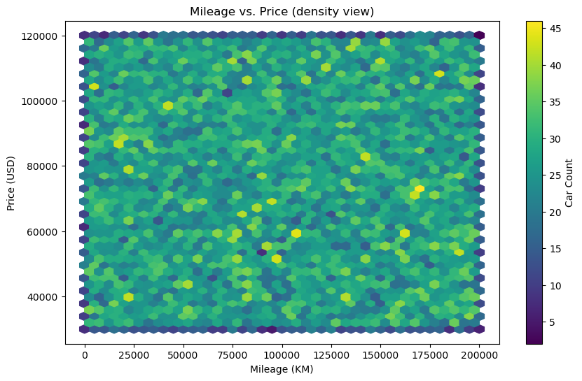

```python
plt.figure(figsize=(10,6))
plt.hexbin(df['Mileage_KM'],df['Price_USD'],gridsize=40)
plt.colorbar(label='Car Count')
plt.title("Mileage vs. Price (density view)")
plt.xlabel("Mileage (KM)")
plt.ylabel("Price (USD)")
plt.show()
```

### Fuel type distribution

This chart analysis shows fairly evenly distributed across different fuel types

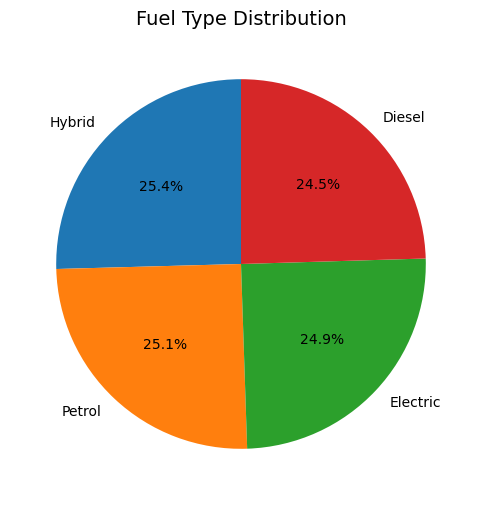

```python
plt.figure(figsize=(8,5))
df["Fuel_Type"].value_counts().plot(kind="pie",autopct='%1.1f%%',startangle=90,figsize=(6,6))
plt.title("Fuel Type Distribution", fontsize=14)
plt.ylabel("")
plt.show()
```

### correlation heatmap

```
This heatmap shows the correlation between the numeric values in BMW dataset
```

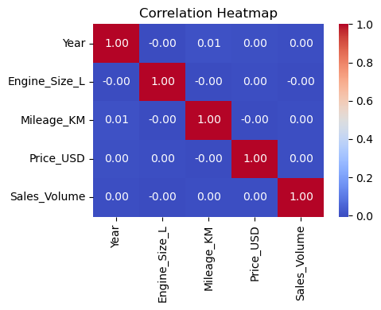

```python
numeric_df=df.select_dtypes(include=[np.number])
if len(numeric_df.columns)>=4:
    plt.figure(figsize=(5,4))
    corr=numeric_df.corr()
    sns.heatmap(corr,annot=True,cmap='coolwarm',fmt='.2f')
    plt.title('Correlation Heatmap')
    plt.tight_layout()
    plt.show()
else:
    print('Not enough numeric columns for a correlation heatmap')
```

### barplot for Price vs Engine size

```
This barplot the price differ against the engine size by the fuel type
```

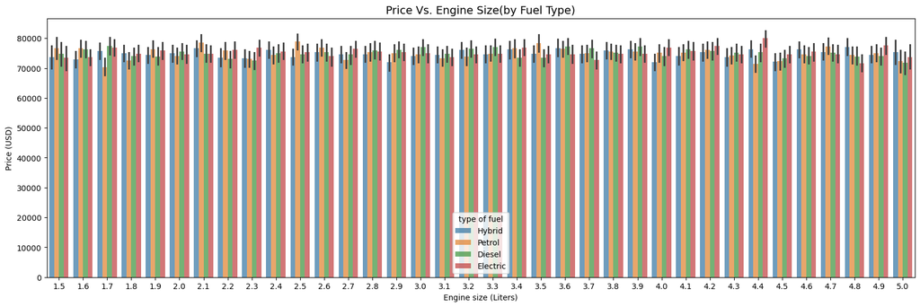

```python
plt.figure(figsize=(20,6))
sns.barplot(data=df,x="Engine_Size_L",y="Price_USD",hue="Fuel_Type",alpha=0.7)
plt.title("Price Vs. Engine Size(by Fuel Type)",fontsize=14)
plt.xlabel("Engine size (Liters)")
plt.ylabel("Price (USD)")
plt.legend(title="type of fuel")
plt.show()
```

## save output

```python
import os
print("operating system:",os.name)
print("current working Directory:",os.getcwd())
```

```
operating system: nt
current working Directory: C:\Users\thama
```

```python
from sklearn.preprocessing import MinMaxScaler
df=pd.read_csv("C:\master program in data analytics\FITA\project 1.csv")
print(df.head())
```

```
      Model  Year         Region  Color Fuel_Type Transmission  Engine_Size_L  \
0  5 Series  2016           Asia    Red    Petrol       Manual            3.5
1        i8  2013  North America    Red    Hybrid    Automatic            1.6
2  5 Series  2022  North America   Blue    Petrol    Automatic            4.5
3        X3  2024    Middle East   Blue    Petrol    Automatic            1.7
4  7 Series  2020  South America  Black    Diesel       Manual            2.1

   Mileage_KM  Price_USD  Sales_Volume Sales_Classification
0      151748      98740          8300                 High
1      121671      79219          3428                  Low
2       10991     113265          6994                  Low
3       27255      60971          4047                  Low
4      122131      49898          3080                  Low
```

```python
df.to_csv("project 1.csv",index=False)
print("summary saves as project 1.csv")
```

```
summary saves as project 1.csv
```

### conclusion

This analysis also provides a strong foundation for future sales forecasting and market prediction, especially in the area of electric vehicle adoption.